# Beginner workflow: finding spatial domains with CellCharterR

Christian Peralta Viteri

22 October 2026

# Contents

> **Independent implementation:** CellCharterR is an independent R implementation of methods described by the CellCharter project. It is not affiliated with, endorsed by, or maintained by the original CellCharter authors or the Computational Systems Oncology group. Questions and bug reports concerning CellCharterR should be directed to the [CellCharterR issue tracker](https://github.com/cperalta-viteri/CellCharterR/issues), not to the upstream CellCharter project.

## 1 What this workflow does

This is the first CellCharterR tutorial. It introduces the complete workflow on a small object that is safe to run on an ordinary CPU. Continue afterwards to the [full mouse-spleen reproduction](https://cperalta-viteri.github.io/CellCharterR/docs/CellCharterR-mouse-spleen-reproducibility.html), which applies the scientific protocol to all observations, and then to the [additional downstream analyses](https://cperalta-viteri.github.io/CellCharterR/docs/CellCharterR-differential-neighborhood-networks.html).

Spatial assays measure many spots while retaining each spot’s position in a tissue. CellCharterR groups spots into **spatial domains**: regions whose spots have similar molecular measurements and similar neighborhoods.

This vignette uses a portable 1,000-spot CODEX teaching subset. It is an exact seeded random subset of the canonical mouse-spleen object, but it is deliberately too small to reproduce or interpret the full biological result. Its purpose is to show the complete interface safely, offline, and on a CPU.

The workflow has five ideas:

1. keep measurements, canonical spatial coordinates, annotations, and results together in one `SpatialExperiment` (SPE), a spatially aware subclass of `SingleCellExperiment`;
2. connect nearby spots separately within each physical tissue section;
3. summarize each spot and its graph neighborhoods;
4. repeat Gaussian-mixture clustering for candidate K values and choose a stable number of domains; and
5. describe which cell types and domain-domain contacts are enriched.

### 1.1 Short glossary

- **Spot:** one measured spatial observation and one column of the SPE.
- **Marker:** a measured protein feature, stored as a row of the `protein` assay.
- **Representation or embedding:** a compact numeric description of each spot; this example uses the fixed published trVAE representation.
- **Spatial graph:** links between nearby spots on the same physical slide.
- **Graph hop:** one step along that graph; two hops reach neighbors of direct neighbors while excluding spots already reached sooner.
- **Domain:** a cluster defined from a spot and its spatial neighborhood.
- **Enrichment:** observed abundance or contact divided by its analytical expectation, displayed here as log2 fold change where stated.
- **Biological replicate/library:** one independently sampled slide. It—not an individual spot—is the permutation unit for condition comparisons.

## 2 Load and inspect the teaching object

```r
library(CellCharterR)
spe <- cellcharter_mouse_spleen_tiny()
spe
```

```
#> class: SpatialExperiment
#> dim: 29 1000
#> metadata(1): CellCharterR
#> assays(1): protein
#> rownames(29): CD45 Ly6C ... CD44 NKp46
#> rowData names(1): marker
#> colnames(1000): 2131 2320 ... 72769-7 73505-7
#> colData names(14): area cell_type ... r_domain_k11_sensitivity
#>   sample_id
#> reducedDimNames(2): X_trVAE X_cellcharter
#> mainExpName: NULL
#> altExpNames(0):
#> spatialCoords names(2) : x y
#> imgData names(0):
```

Each column is a spatial spot. The `protein` assay contains marker intensities, `spatialCoords(spe)` contains canonical x/y positions, and `X_trVAE` is the fixed representation used by the published CellCharter tutorial.

```r
SummarizedExperiment::assayNames(spe)
```

```
#> [1] "protein"
```

```r
SingleCellExperiment::reducedDimNames(spe)
```

```
#> [1] "X_trVAE"       "X_cellcharter"
```

```r
SpatialExperiment::spatialCoordsNames(spe)
```

```
#> [1] "x" "y"
```

```r
head(SummarizedExperiment::colData(spe)[, c("sample", "condition", "cell_type")])
```

```
#> DataFrame with 6 rows and 3 columns
#>        sample condition cell_type
#>      <factor>  <factor>  <factor>
#> 2131  BALBc-1     BALBc   B cells
#> 2320  BALBc-1     BALBc   B cells
#> 5142  BALBc-1     BALBc   B cells
#> 5453  BALBc-1     BALBc   B cells
#> 6311  BALBc-1     BALBc   B cells
#> 6317  BALBc-1     BALBc   B cells
```

```r
table(SummarizedExperiment::colData(spe)$sample)
```

```
#>
#> BALBc-1 BALBc-2 BALBc-3   MRL-4   MRL-5   MRL-6   MRL-7   MRL-8   MRL-9
#>     118     118     120     115      89     126     118      96     100
```

For the compact teaching plots, `cell_type_reduced` is a precomputed grouping of closely related detailed `cell_type` labels. The full-data reports retain the complete 27-level annotation instead.

```r
head(unique(data.frame(
  detailed = as.character(spe$cell_type),
  teaching_group = as.character(spe$cell_type_reduced)
)))
```

```
#>                                   detailed     teaching_group
#> 1                                  B cells            B cells
#> 47                      B220(+) DN T cells B220(+) DN T cells
#> 48        CD106(+)CD16/32(+)CD31(+) stroma             stroma
#> 49 CD106(+)CD16/32(+)CD31(-)Ly6C(-) stroma             stroma
#> 55                CD3(+) other markers (-)              other
#> 58                          CD4(+) T cells     CD4(+) T cells
```

## 3 Run the workflow one stage at a time

The candidate range is declared before fitting: K=2 through K=10. CellCharter’s neighboring-K calculation also fits the two boundary models needed to score that range. The tutorial uses three repeated runs to keep package builds short; a scientific analysis should retain the package default `max_runs = 10` and `convergence_tol = 0.01`.

The individual calls below are the recommended way to learn the workflow and the required approach for a large dataset: each object has a clear location, and expensive stages can be saved independently. They are displayed rather than executed during package building; the validated result is loaded afterwards so every following output remains visible.

```r
checkpoint_dir <- "checkpoints/tiny_autok"
dir.create(checkpoint_dir, recursive = TRUE, showWarnings = FALSE)
```

### 3.1 1. Construct the sample-local spatial graph

```r
spe <- cellcharter_graph(
  spe,
  spatial = "spatial",
  sample_col = "sample",
  graph_name = "cellcharter_graph",
  percentile = 99
)
```

### 3.2 2. Aggregate exclusive graph-hop representations

Aggregation remains in memory by default, avoiding an additional backing-file dependency. If the representation does not fit comfortably in RAM, supply `filepath = "checkpoints/X_cellcharter.h5"` as an optional low-memory mode and retain that file with the object.

```r
spe <- cellcharter_aggregate(
  spe,
  representation = "X_trVAE",
  graph_name = "cellcharter_graph",
  sample_col = "sample",
  output = "X_cellcharter_tiny",
  n_layers = 3L
)
```

Save the post-aggregation object before a long AutoK run:

```r
dir.create("checkpoints", recursive = TRUE, showWarnings = FALSE)
saveRDS(spe, "checkpoints/spe_after_aggregation.rds", compress = FALSE)
```

### 3.3 3. Run AutoK and attach the selected domains

The call below records the exact compiled C++ settings that generated the packaged teaching result loaded later in this vignette. The settings are intentionally small for the 1,000-spot object.

#### 3.3.1 Configure CPU threading before a parallel C++ run

The compiled backend parallelizes at two levels: `workers` fits can run at the same time, and each fit can use `threads_per_fit` threads. A multithreaded BLAS under every worker would add a hidden third level of parallelism. This nested oversubscription can create far more runnable threads than the machine has CPU cores, increasing memory pressure and often making the analysis substantially slower.

For a parallel compiled run, place the following entries in the analysis project’s `.Renviron` file **before starting R**, then restart R. In RStudio, `file.edit(".Renviron")` opens the project-local file.

```
OPENBLAS_NUM_THREADS=1
OMP_NUM_THREADS=1
MKL_NUM_THREADS=1
BLIS_NUM_THREADS=1
VECLIB_MAXIMUM_THREADS=1
GOTO_NUM_THREADS=1
```

These settings make only the linked BLAS/OpenMP runtime single-threaded; they do not make CellCharterR sequential. CellCharterR still uses up to `workers * threads_per_fit` threads. Setting all six variables makes the setup portable across common BLAS implementations. Confirm the values before loading CellCharterR:

```r
Sys.getenv(c(
  "OPENBLAS_NUM_THREADS", "OMP_NUM_THREADS", "MKL_NUM_THREADS",
  "BLIS_NUM_THREADS", "VECLIB_MAXIMUM_THREADS", "GOTO_NUM_THREADS"
))
```

```r
spe <- cellcharter_cluster(
  spe,
  representation = "X_cellcharter_tiny",
  candidate_k = c(2L, 10L),
  checkpoint_dir = checkpoint_dir,
  domain_col = "tiny_domain",
  max_runs = 3L,
  convergence_tol = 0.01,
  seed = 1L,
  backend = "cpp",
  workers = 2L,
  threads_per_fit = 1L,
  checkpoint_mode = "none",
  fit_args = list(max_iter = 20L),
  resume = FALSE
)
```

The packaged teaching run disables fit checkpoints because it finishes in seconds. For a longer analysis, use round-level checkpoints from the beginning. After an interruption, load the saved post-aggregation SPE and repeat the exact same call with `resume = TRUE`:

```r
spe <- readRDS("checkpoints/spe_after_aggregation.rds")
checkpoint_dir <- "checkpoints/tiny_autok_cpp_resumable"

spe <- cellcharter_cluster(
  spe,
  representation = "X_cellcharter_tiny",
  candidate_k = c(2L, 10L),
  checkpoint_dir = checkpoint_dir,
  domain_col = "tiny_domain",
  max_runs = 3L,
  convergence_tol = 0.01,
  seed = 1L,
  backend = "cpp",
  workers = 2L,
  threads_per_fit = 1L,
  checkpoint_mode = "round",
  fit_args = list(max_iter = 20L),
  resume = TRUE
)
```

Use `max_runs = 10L` and the default model iteration limit for a scientific analysis. The smaller values above only bound vignette work. For larger runs, choose `workers * threads_per_fit` no larger than the CPU threads and memory bandwidth available to the R session. Round-level checkpointing writes one atomic bundle after all K fits in a round finish; use `checkpoint_mode = "fit"` when preserving every completed K is more important than fitting K values concurrently. R Torch/CUDA remains available through `backend = "torch"`, but is experimental for multi-million-observation data.

### 3.4 4. Compute downstream statistics

```r
spe <- cellcharter_enrichment(
  spe, group_col = "cell_type_reduced", domain_col = "tiny_domain"
)
spe <- cellcharter_nhood_enrichment(
  spe, graph_name = "cellcharter_graph", domain_col = "tiny_domain"
)
spe <- cellcharter_diff_nhood_enrichment(
  spe,
  graph_name = "cellcharter_graph",
  domain_col = "tiny_domain",
  condition_col = "condition",
  sample_col = "sample",
  condition_groups = c("BALBc", "MRL"),
  n_perms = 10L,
  seed = 1L
)
```

### 3.5 Optional compact wrapper

`cellcharter_workflow()` composes exactly those stages. It is convenient for small examples, but staged calls with durable output paths are safer for large experiments.

```r
spe <- cellcharter_workflow(
  spe,
  group_col = "cell_type_reduced",
  candidate_k = c(2L, 10L),
  checkpoint_dir = checkpoint_dir,
  spatial = "spatial",
  representation = "X_trVAE",
  sample_col = "sample",
  condition_col = "condition",
  aggregated = "X_cellcharter_tiny",
  domain_col = "tiny_domain",
  condition_groups = c("BALBc", "MRL"),
  n_perms = 10L,
  seed = 1L,
  autok_args = list(
    max_runs = 3L,
    convergence_tol = 0.01,
    backend = "cpp",
    workers = 2L,
    threads_per_fit = 1L,
    checkpoint_mode = "none",
    fit_args = list(max_iter = 20L),
    resume = FALSE
  )
)
```

The graph is stored in `colPairs()`, the aggregate representation in `reducedDims()`, domain labels in `colData()`, and fitted-stage provenance and statistical results in `metadata()`.

```r
SingleCellExperiment::colPairNames(spe)
```

```
#> [1] "cellcharter_graph"
```

```r
SingleCellExperiment::reducedDimNames(spe)
```

```
#> [1] "X_trVAE"            "X_cellcharter"      "X_cellcharter_tiny"
```

```r
table(SummarizedExperiment::colData(spe)$tiny_domain)
```

```
#>
#>   0   1
#> 468 532
```

```r
names(S4Vectors::metadata(spe)$CellCharterR$results)
```

```
#> [1] "enrichment"            "nhood_enrichment"      "diff_nhood_enrichment"
```

The graph was built independently for every slide before applying one global distance cutoff. This is essential: geometrically close coordinates from two different tissue sections are not biological neighbors. The following check must be `TRUE`.

```r
pairs <- SingleCellExperiment::colPair(spe, "cellcharter_graph")
sample_id <- as.character(SummarizedExperiment::colData(spe)$sample)
all(sample_id[S4Vectors::from(pairs)] == sample_id[S4Vectors::to(pairs)])
```

```
#> [1] TRUE
```

`X_cellcharter_tiny` concatenates the original representation with exclusive one-, two-, and three-hop means. “Exclusive” means that a spot reached in one hop is not counted again in the two-hop block. These features let the GMM distinguish spots with similar marker states but different tissue contexts.

## 4 Diagnose the choice of K

AutoK compares solutions at neighboring K values with the Fowlkes–Mallows score. Peaks suggest comparatively stable resolutions; they are diagnostics, not biological proof. The selected K is the highest mean stability, with the first K used to break ties.

```r
autok <- S4Vectors::metadata(spe)$CellCharterR$autok$tiny_domain
cellcharter_autok_best_k(autok)
```

```
#> [1] 2
```

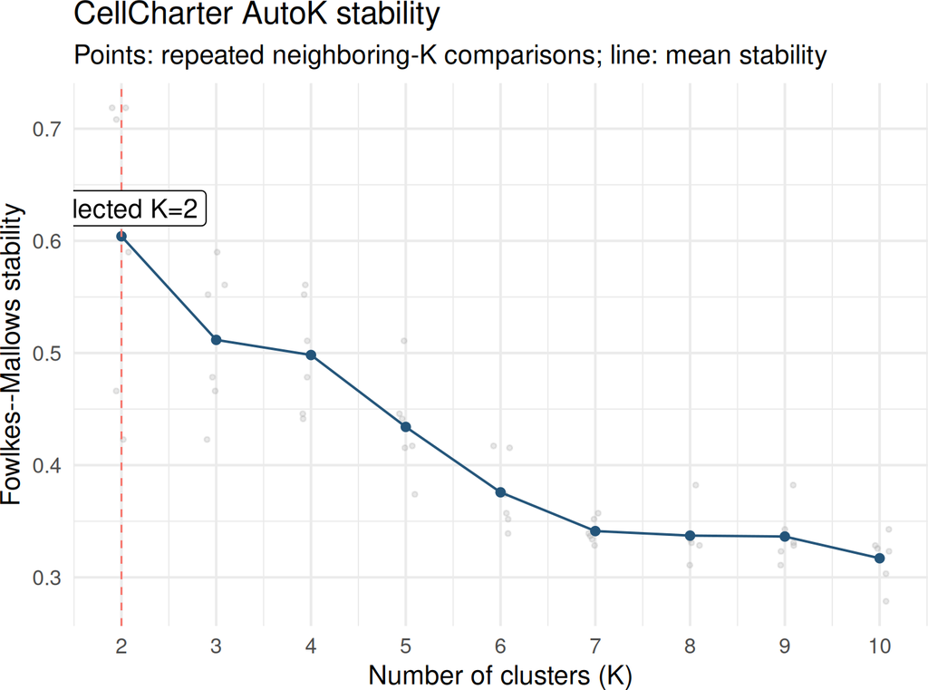

Figure 1: AutoK neighboring-K stability across the candidate range K=2 through K=10 for the tiny teaching data

```r
cellcharter_plot_autok_stability(autok, k_range = 2:10) +
  ggplot2::theme_minimal(base_size = 16)
```

### 4.1 Save the completed AutoK search and revisit another K

`checkpoint_mode = "none"` disables writes *while AutoK is running*; it does not discard a successful search. After `cellcharter_cluster()` returns, the SPE contains the selected labels in `colData()` and the complete AutoK result in `metadata()`. For a no-checkpoint run, that result is self-contained: it keeps the lowest-negative-log-likelihood model and labels for every fitted K. Save the returned SPE before ending the R session:

```r
saveRDS(
  spe,
  "checkpoints/spe_after_autok.rds",
  compress = FALSE
)

# Saving only AutoK is also possible when the spatial object is stored elsewhere.
autok <- S4Vectors::metadata(spe)$CellCharterR$autok$tiny_domain
saveRDS(autok, "checkpoints/tiny_autok_complete.rds", compress = FALSE)
```

The stability curve can then be inspected in a later session without fitting the GMMs again:

```r
spe <- readRDS("checkpoints/spe_after_autok.rds")
autok <- S4Vectors::metadata(spe)$CellCharterR$autok$tiny_domain

cellcharter_autok_best_k(autok)
cellcharter_plot_autok_stability(autok, k_range = 2:10)
```

Suppose the stability plot motivates inspecting K=4 even though AutoK selected another resolution. AutoK already fitted K=4, so the best K=4 labels can be attached under a new `colData()` name without repeating the search:

```r
k4_model <- cellcharter_autok_model(autok, k = 4L)
k4_labels <- k4_model$labels
stopifnot(length(k4_labels) == ncol(spe), !anyNA(k4_labels))

spe$tiny_domain_k4 <- factor(
  k4_labels,
  levels = sort(unique(k4_labels))
)
table(spe$tiny_domain_k4)
```

This recovery is available only after the call completes and the returned SPE or AutoK object is saved. If R is interrupted during a no-checkpoint search, the unfinished work is lost. Use `checkpoint_mode = "round"` or `"fit"` when mid-run recovery is required; in those modes, retain the checkpoint directory because the AutoK result refers to its fitted-model artifacts.

## 5 Map the teaching domains

`ggspavis` plots annotations directly from a `SpatialExperiment`. Its current `plotCoords()` function is the renamed successor to `plotSpots()` in older releases. The small compatibility branch below supports both APIs. We subset the SPE itself, so its native coordinates, annotations, and sample identifiers remain aligned automatically.

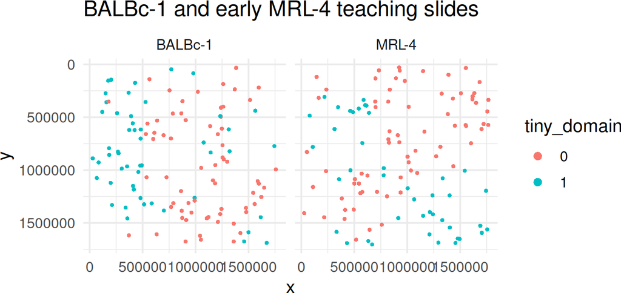

Figure 2: Spatial distribution of the teaching domain labels in the BALBc-1 and early MRL-4 slides

```r
display_spe <- spe[, spe$sample %in% c("BALBc-1", "MRL-4")]
plot_function <- if ("plotCoords" %in% getNamespaceExports("ggspavis")) {
  getExportedValue("ggspavis", "plotCoords")
} else {
  getExportedValue("ggspavis", "plotSpots")
}
plot_arguments <- list(
  spe = display_spe,
  annotate = "tiny_domain",
  sample_id = "sample_id",
  point_size = 1.2
)
if ("in_tissue" %in% names(formals(plot_function))) {
  plot_arguments <- c(plot_arguments, list(in_tissue = NULL))
}
do.call(plot_function, plot_arguments) +
  ggplot2::labs(colour = "Domain", title = "BALBc-1 and early MRL-4 teaching slides") +
  ggplot2::theme_minimal(base_size = 16)
```

The count table below provides the same domain identity without relying on colour perception.

```r
as.data.frame(table(
  sample = display_spe$sample,
  domain = display_spe$tiny_domain
))
```

```
#>     sample domain Freq
#> 1  BALBc-1      0   67
#> 2  BALBc-2      0    0
#> 3  BALBc-3      0    0
#> 4    MRL-4      0   72
#> 5    MRL-5      0    0
#> 6    MRL-6      0    0
#> 7    MRL-7      0    0
#> 8    MRL-8      0    0
#> 9    MRL-9      0    0
#> 10 BALBc-1      1   51
#> 11 BALBc-2      1    0
#> 12 BALBc-3      1    0
#> 13   MRL-4      1   43
#> 14   MRL-5      1    0
#> 15   MRL-6      1    0
#> 16   MRL-7      1    0
#> 17   MRL-8      1    0
#> 18   MRL-9      1    0
```

If `ggspavis` is unavailable in a minimal installation, the coordinates and labels remain directly accessible for a dependency-light custom plot through `SpatialExperiment::spatialCoords(spe)` and `spe$tiny_domain`.

Do not interpret this map as a mouse-spleen reproduction: random subsampling changes the spatial graph and therefore its neighborhoods.

## 6 Inspect enrichment results

The cell-type result compares the observed cell-type proportion inside each domain with the cohort-wide expectation. Neighborhood enrichment is directed: row-domain contact with column-domain need not have the same normalized value as the reverse direction. Differential neighborhood enrichment permutes the condition assignment at the **sample/library level**, never spot by spot.

```r
results <- S4Vectors::metadata(spe)$CellCharterR$results
round(results$enrichment$value$enrichment, 2)
```

```
#>                        0     1
#> B cells            -0.24  0.18
#> B220(+) DN T cells -0.33  0.24
#> CD11c(+) B cells   -1.23  -Inf
#> CD31(hi) vascular  -1.23  -Inf
#> CD4(+) T cells     -0.53  0.35
#> CD8(+) T cells     -0.70  0.42
#> DCs                -0.20  0.16
#> erythroblasts       0.72 -1.21
#> F4/80(+) mphs       0.33 -0.37
#> FDCs               -0.49  0.33
#> granulocytes        0.59 -0.86
#> marginal zone mphs  0.83 -1.67
#> megakaryocytes      1.10  -Inf
#> NK cells            0.10 -0.09
#> other               0.78 -1.45
#> plasma cells       -1.23  0.59
#> stroma              0.31 -0.34
```

```r
round(results$nhood_enrichment$value$enrichment, 2)
```

```
#>      0    1
#> 0   NA 0.47
#> 1 0.53   NA
```

```r
round(results$diff_nhood_enrichment$value$effect, 2)
```

```
#>       0    1
#> 0    NA 0.01
#> 1 -0.01   NA
```

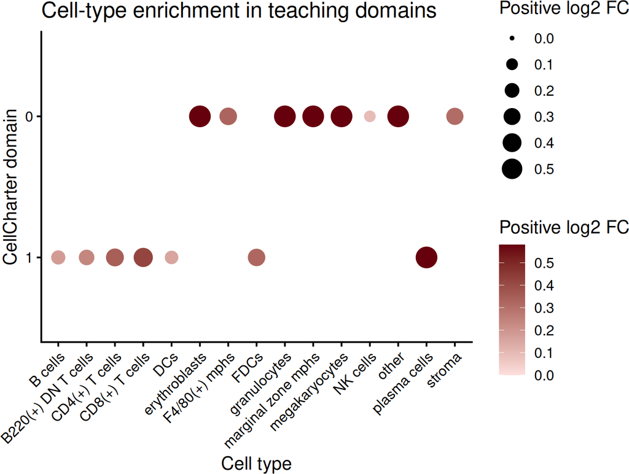

Figure 3: Positive cell-type enrichment in the teaching domains  
Darker and larger red points indicate stronger positive log2 fold change.

```r
enrichment <- results$enrichment$value$enrichment
cellcharter_plot_enrichment(
  spe,
  title = "Cell-type enrichment in teaching domains"
)
```

Displayed points are more common in a domain than expected from their overall abundance. Non-positive associations remain available in the enrichment matrix but are omitted from this CellCharter-style plot so depletion does not dominate the display. Darker and larger red points indicate stronger positive enrichment, capped at the tutorial display threshold of 0.58. For example, the code below reports the strongest finite enrichment and depletion in this teaching subset. These are demonstrations, not full-data biological conclusions.

```r
finite_index <- which(is.finite(enrichment), arr.ind = TRUE)
finite_values <- enrichment[finite_index]
extreme_index <- finite_index[c(which.max(finite_values), which.min(finite_values)), , drop = FALSE]
data.frame(
  direction = c("strongest enrichment", "strongest depletion"),
  cell_type = rownames(enrichment)[extreme_index[, "row"]],
  domain = colnames(enrichment)[extreme_index[, "col"]],
  log2_fc = enrichment[extreme_index]
)
```

```
#>              direction          cell_type domain   log2_fc
#> 1 strongest enrichment     megakaryocytes      0  1.095420
#> 2  strongest depletion marginal zone mphs      1 -1.674461
```

An enrichment value of `-Inf` is not a numerical failure: it means the observed proportion is zero while the expected proportion is positive, so its log2 fold change is negative infinity. The table deliberately reports finite extremes.

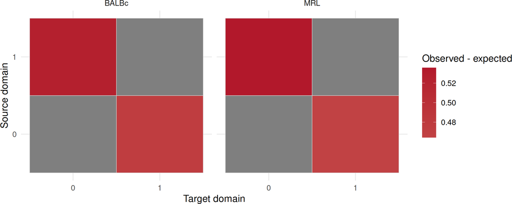

Figure 4: Directed observed-minus-expected neighborhood enrichment for the healthy BALBc and lupus MRL teaching samples

```r
condition_matrices <- results$diff_nhood_enrichment$value$enrichment
condition_long <- do.call(rbind, lapply(names(condition_matrices), function(condition) {
  value <- as.data.frame(as.table(condition_matrices[[condition]]))
  names(value) <- c("source", "target", "enrichment")
  value$condition <- condition
  value
}))
ggplot2::ggplot(condition_long,
                ggplot2::aes(target, source, fill = enrichment)) +
  ggplot2::geom_tile(colour = "grey85") +
  ggplot2::facet_wrap(~condition) +
  ggplot2::scale_fill_gradient2(low = "#2166AC", mid = "white", high = "#B2182B") +
  ggplot2::labs(x = "Target domain", y = "Source domain",
                fill = "Observed - expected") +
  ggplot2::theme_minimal(base_size = 16)
```

Here each condition panel shows CellCharter’s directed neighborhood statistic, `observed - expected`; it is not a fold change. Rows are source domains and columns are target domains.

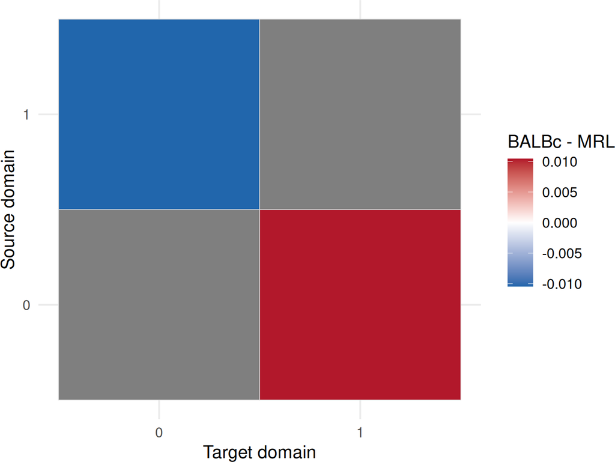

Figure 5: Differential directed neighborhood enrichment for the BALBc-minus-MRL contrast in the teaching data

```r
effect <- results$diff_nhood_enrichment$value$effect
effect_long <- as.data.frame(as.table(effect))
names(effect_long) <- c("source", "target", "effect")
ggplot2::ggplot(effect_long, ggplot2::aes(target, source, fill = effect)) +
  ggplot2::geom_tile(colour = "grey85") +
  ggplot2::scale_fill_gradient2(low = "#2166AC", mid = "white", high = "#B2182B") +
  ggplot2::labs(x = "Target domain", y = "Source domain",
                fill = "BALBc - MRL") +
  ggplot2::theme_minimal(base_size = 16)
```

The differential panel is the first categorical condition level minus the second (`BALBc - MRL` here), calculated from the condition-specific `observed - expected` matrices. Its empirical, unadjusted p-values are:

```r
round(results$diff_nhood_enrichment$value$pvalue, 2)
```

```
#>     0   1
#> 0 0.0 0.4
#> 1 0.4 0.0
```

The ten permutations above are only a quick teaching demonstration. The CODEX reproduction uses 100, as required by the tutorial protocol.

The parity permutation deliberately reproduces CellCharter 0.2.0: libraries are drawn with replacement and empirical p-values use the historical directional count without a plus-one correction. P-values are unadjusted across domain pairs. Interpret the effect size before its p-value, and treat results as associations rather than causal interactions. For a new study, consider the documented `permutation_mode = "shuffle"` alternative and a suitable multiple-testing correction. Domain stability depends on the representation, spatial graph, candidate K range, and mixture initialization; K is a diagnostic resolution, not a biological truth.

## 7 Identity and subsetting safeguards

`spatialCoords()`, `colPairs()` endpoints, reduced dimensions, and `colData()` subset together with the SPE. Dataset-level fitted results in `metadata()`, however, no longer describe the subset. CellCharterR records ordered-observation digests and refuses to reuse such stages until they are recomputed.

```r
smaller <- spe[, seq_len(100)]
dim(SingleCellExperiment::colPair(smaller, "cellcharter_graph"))
```

[output not shown]

```r
try(cellcharter_aggregate(
  smaller,
  representation = "X_trVAE",
  graph_name = "cellcharter_graph",
  output = "recomputed"
))
```

```
#> Error : CellCharterR stage `graph:cellcharter_graph` is stale after spot reordering or subsetting; recompute it.
```

The displayed error is expected: it demonstrates that CellCharterR detects the changed ordered-observation identity and refuses to reuse a graph-stage contract from the 1,000-spot object on a 100-spot subset. Rebuild the graph on `smaller` before aggregating it.

## 8 Moving to a real analysis

The complete mouse-spleen analysis is the primary CellCharterR reproducibility report. It contains the full visible code, pinned versions, checkpoints, compiled-C++ AutoK-selected K=10 result, separately labelled K=11 sensitivity analysis, cell-type enrichment, neighborhood enrichment, and differential neighborhood enrichment. [Open the complete mouse-spleen reproducibility report](https://cperalta-viteri.github.io/CellCharterR/docs/CellCharterR-mouse-spleen-reproducibility.html).

For a real dataset whose aggregated representation fits comfortably in RAM, leave `filepath = NULL` and save the post-aggregation object directly. Use `cellcharter_aggregate(..., filepath = ...)` only when RAM is limiting; in that mode retain the aggregation HDF5 file with the object. Place AutoK checkpoints under a durable results directory, use `max_runs = 10`, and decide the K range before looking at stability. Biological conclusions require the complete dataset and appropriate replication; they must not be inferred from this teaching subset.

If the real SPE was created with `cellcharter_import_h5ad()`, its import directory is already independent of the source H5AD. Persist completed stages in that same directory with `cellcharter_save_spe(spe, spe_dir)`, then restore them with `cellcharter_load_spe(spe_dir)`. This updates only the mutable state: it never rewrites the large `arrays.h5`. The default `retain_generations = 1L` prevents repeated saves from accumulating old state; `cellcharter_load_spe(spe_dir, restore_state = FALSE)` remains available to recover the immutable imported base without applying saved analysis state. AutoK/fixed-K models, stability objects, stage metadata, and checkpoint locators are omitted from the SPE state regardless of checkpoint mode. No checkpoint directory is copied into the SPE directory. Labels in `colData` and graphs in `colPairs` remain portable; retain checkpoints separately when resume, stability inspection, or model retrieval is needed.

The companion H5AD vignette provides checksum-safe, unevaluated download code. The two official H5AD files total 600.4 MiB; reserve additional working space for HDF5 aggregation and checkpoints. The portable full spatial object is 286.0 MiB on disk and about 693.7 MiB after loading. Full AutoK repeats many GMM fits, so runtime is hardware- and K-range-dependent; use a durable checkpoint directory and resume completed fits rather than restarting. The preserved full report records the publication-scale parameters and limitations. If a stage fails, first inspect its recorded seed, observation-order digest, sample field, CPU thread count, and checkpoint contract.

## 9 References

The full reproducibility report cites CellCharter (Varrone et al., 2024), the CODEX mouse-spleen dataset (Goltsev et al., 2018), and the pinned CellCharter 0.2.0 source commit used for parity.

## 10 Citing CellCharterR

Christian Peralta Viteri is the author and maintainer of CellCharterR. Retrieve the package’s current, version-aware citation and copyable BibTeX with:

```r
citation("CellCharterR")
```

```
#>
#>   Peralta Viteri C (2026). _CellCharterR: Disk-Backed R Implementation
#>   of CellCharter Spatial Domains_. R package version 0.99.0,
#>   <https://github.com/cperalta-viteri/CellCharterR>.
#>
#> A BibTeX entry for LaTeX users is
#>
#>   @Manual{,
#>     title = {CellCharterR: Disk-Backed R Implementation of CellCharter Spatial Domains},
#>     author = {Christian {Peralta Viteri}},
#>     year = {2026},
#>     note = {R package version 0.99.0},
#>     url = {https://github.com/cperalta-viteri/CellCharterR},
#>   }
#>
#> Depending on the analysis, also cite the underlying CellCharter method
#> (doi:10.1038/s41588-023-01588-4). For the bundled CODEX teaching data,
#> also cite Goltsev et al. (2018), doi:10.1016/j.cell.2018.07.010,
#> dataset doi:10.17632/zjnpwh8m5b.1, and the CC BY 4.0 clustered-data
#> record doi:10.6084/m9.figshare.25040192.v2.
```